# What is political science, and how do we do scientific research?

PSCI 2270 - Lecture 1

Georgiy Syunyaev

Department of Political Science, Vanderbilt University

August 29, 2024

## More about me

- What made you want to come to back to the US?
- Why did you choose to go down the academic path?
- What is your favourite part about conducting political research?
- If you had three keywords what would they be?

## Plan for this week

1. What is (political) science?
2. Empirical method
3. Looking for questions
4. Coming up with theory
5. Causal and descriptive inference
6. How to read articles

## What is science?

**Science is…**

*A systematic enterprise that builds and organizes knowledge in the form of testable explanations and predictions about the universe*

- Goal: Systematic knowledge
- Conclusions: Have uncertainty
- Disciplined thinking: Empirical or formal logic
- Knowledge accumulation: Itterative

## Science is curiosity

[figure not shown]

## What is political science?

- Political science: Science that…
  - Studies human behavior and institutions
  - Anything related to politics/governance/policy-making (i.e. pretty much everything)
- *“Politics is more difficult than physics.”* — Albert Einstein
- Studying $\Rightarrow$ explaining political phenomena
  - Causal inference: Effect of $X$ on $Y$
  - Descriptive inference: Measure $X$ or $Y$
- But how are we different from political/investigative journalism?

We have METHOD 🤯

## Empirical method

#### What we should do:

1. Ask question (puzzle)
2. Come up with theory (model)
3. Derive hypotheses (inquiries)
4. Collect data
5. Test hypotheses (analysis)
6. Interpret
7. Adjust theory (remodel)

#### What we do in (bad) reality:

1. Uhh…
2. Mix of:
   - Systematic searching
   - Accidental discovery
3. Discover patterns in data
4. Come up with some (*ad hoc*) explanation
5. Claim this is what you expected

🫠

## Even more in reality

[figure not shown]

## Back to good practice

#### What we should do:

1. Ask question (puzzle)
2. Come up with theory (model)
3. Derive hypotheses (inquiries)
4. Collect data
5. Test hypotheses (analysis)
6. Interpret
7. Adjust theory (remodel)

[output not shown]

Be TRANSPARENT! 🫥

## Looking for *the Question*

- Personal experiences and histories!
- News/Blogs:
  - [Financial Times](https://www.ft.com/), [NYT/WSJ](https://studentorg.vanderbilt.edu/vsg/project/news/), [Vox](https://www.vox.com/), [Foreign Affairs](https://www.foreignaffairs.com/), [Intercept](https://theintercept.com/),…
  - [Monkey Cage](https://www.washingtonpost.com/monkey-cage/), [Marginal Revolution](https://marginalrevolution.com/),…
- Books, movies/TV series (e.g. *Borgen*, *Veep*, *the Wire*, etc.)
- *“I have stood on the shoulders of giants”* — Isaac Newton
  - ⛏️: [Vanderbilt Library](https://www.library.vanderbilt.edu/), [Google scholar](https://scholar.google.com)
  - 💻: [Elicit](https://elicit.org/), [Semantic Scholar](https://www.semanticscholar.org/), [SCite](https://scite.ai/),…
  - 🤖: ChatGPT or Claude are *NOT* good at creating new questions/reviewing literature
  - [ResearchRabbit](https://researchrabbitapp.com/) for literature networks
- Even social media: *YouTube*, *Twitter (* $\mathbb{X}$ ), *TikTok*, etc.

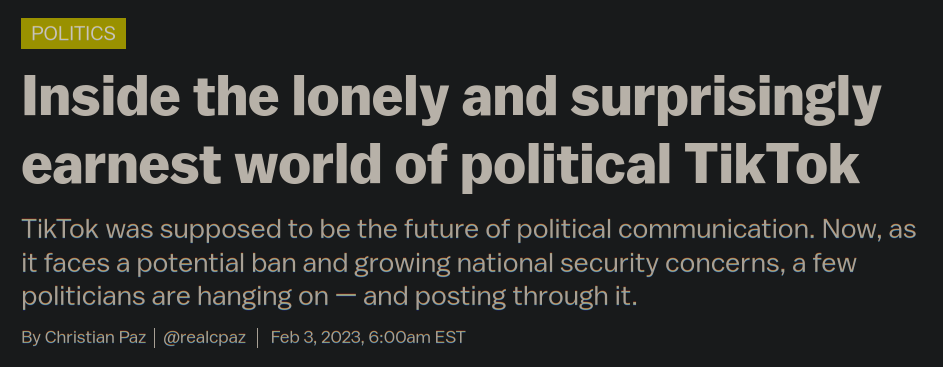

## Theory of *Theories*

- Theory $\Rightarrow$ a **model** of the world that provides explanation of the causal relationship between two variables ($X \rightarrow Y$), or description of one variable (measure of $X$)
- Good models?
  1. **positive:** as *value-free* as possible
  2. **verifiable:** practical possibility of observing outcomes that could corroborate and falsify the theory
  3. **falsifiable:** Karl Popper (1902-1994)
  4. **general:** US Congress $\Rightarrow$ legislative bodies (scope)
  5. **concrete:** clearly defined concepts (not “strength of the leader”, “nature of the voters”, “intelligence of the policy maker”)

## Find good models

*Many individuals are driven in their behavior by their political convictions. Which statement applies to this theory?*

1. Not concrete
2. Not falsifiable
3. Not causal
4. Normative
5. A & D
6. A & B

## Find good models

*Many individuals are driven in their behavior by their political convictions. Which statement applies to this theory?*

1. Not concrete
2. Not falsifiable
3. Not causal
4. Normative
5. A & D
6. A & B

## Find good models

*If German voters had known the extent of Hitler’s extremism (in terms of political ideology and violence perpetrated) they would have not voted for him. Which statement applies to this theory?*

1. Not concrete
2. Not testable
3. Not causal
4. Normative
5. A, B and D

## Find good models

*If German voters had known the extent of Hitler’s extremism (in terms of political ideology and violence perpetrated) they would have not voted for him. Which statement applies to this theory?*

1. Not concrete
2. Not testable
3. Not causal
4. Normative
5. A, B and D

## Find good models

*Immigrants should receive citizenship immediately as soon as they start working legally (any job) in a foreign country. Which statement applies to this theory?*

1. Not concrete
2. Causal
3. Normative
4. B and C

## Find good models

*Immigrants should receive citizenship immediately as soon as they start working legally (any job) in a foreign country. Which statement applies to this theory?*

1. Not concrete
2. Causal
3. Normative
4. B and C

## Find good models

*The best predictor of a vote for Republicans in the United States is the state of the economy in the previous 4 years. Which statement applies to this theory?*

1. Not concrete
2. Not testable
3. Not causal
4. Normative
5. None of the above

## Find good models

*The best predictor of a vote for Republicans in the United States is the state of the economy in the previous 4 years. Which statement applies to this theory?*

1. Not concrete
2. Not testable
3. Not causal
4. Normative
5. None of the above

## Find good models

*Many Trump supporters are rich. Which statement applies to this theory?*

1. Not concrete
2. Not testable
3. Descriptive
4. Normative
5. None of the above

## Find good models

*Many Trump supporters are rich. Which statement applies to this theory?*

1. Not concrete
2. Not testable
3. Descriptive
4. Normative
5. None of the above

## Good models cont’d

- Simplified picture of the world
  - Theoretically
  - Observationally
- Use *Occam’s razor*
  - Prefer parsimony
  - Explain a lot with a little

*“All models are wrong, but some are useful.” — George Box*

[figure not shown]

## Useful Wrong Model

[figure not shown]

## 5 Questions about every theory

1. What’s my question? $\Leftarrow$ Question
2. Why is my question important? $\Leftarrow$ Question
3. What’s my answer to the question? $\Leftarrow$ Model
4. How would I know if I were wrong? $\Leftarrow$ Hypothese $+$ Data $+$ Analysis
5. Was I wrong? $\Leftarrow$ Interpretation $+$ Remodel

## Kenworthy and Pontusson (2005)

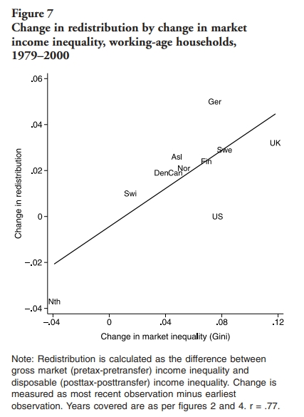

*In a 2005 study, Lane Kenworthy and Jonas Pontusson analyzed trends in the distribution of gross market income-the distribution of income before taxes and government transfers-for affluent Organisation for Economic Co-operation and Development (OECD) countries using data from the Luxembourg Income Study. Kenworthy and Pontusson were interested in whether inequality in market income had increased and to what extent government policies had responded to changes in market income inequality. In particular, they were interested in testing the median-voter model developed by Allan H. Meltzer and Scott F Richards…*

## 💡 Income inequality

REMODEL!

## What if we consider turnout?

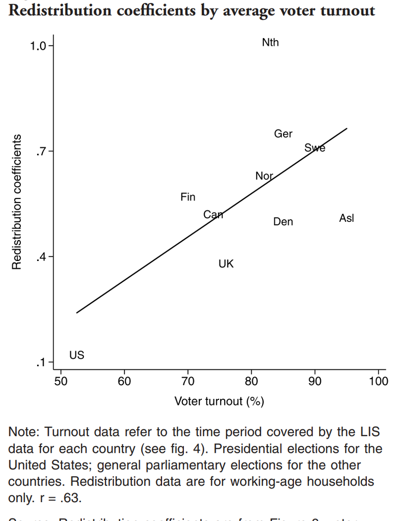

## Mendelberg, Karpowitz, and Oliphant (2014)

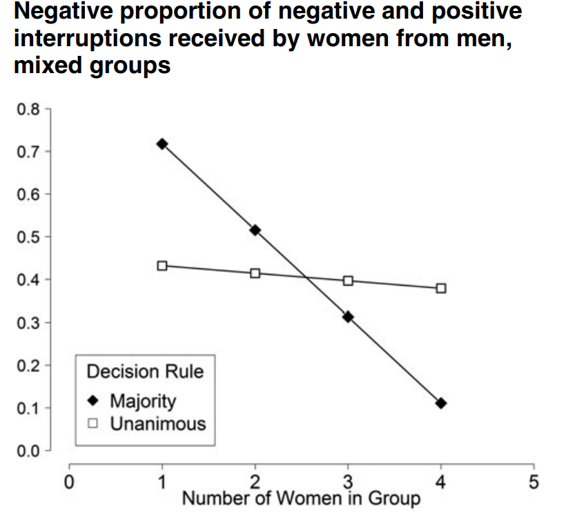

*Is the number of women in a legislative body the critical factor [for substantive representation], or might the rules governing deliberation in the legislature also be important?.. Mendelberg, Karpowitz, and Oliphant’s research investigates whether [this relationship is] affected by a group’s decision rule. They hypothesize that under a unanimous rule, women will receive more respect in deliberations… but only when women are in the minority, not when they predominate (based on previous research). To test their hypothesis, they set up 94 five-member discussion groups composed of between O and 5 women, and randomly assigned each group to unanimous or majority rule. The.researchers … counted the number of times each person spoke and coded the number and tone (positive, neutral, or negative) of interruptions…*

## 💡 Gender gap in politics

- Question: How having more women in politics affect delibiration (substantive representation)?
- Model: Having more women in legislative body can diminish “authoritative use of speech” by men, but this could depend on decision rule (majority vs unanimity)
- Hypothesis: In group discussions women will experience less negative interruptions under unanimity rule (compared to majority rule) but only when they are in minority
- Data/Analysis: Laboratory experiment where 94 five-member groups were randomly assigned gender composition and decision rule to use
- Results: Support for the hypothesis in terms of overall interruptions, but not in terms of positive interruptions

## Butler and Broockman (2011)

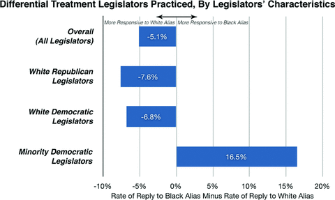

*We use a field experiment to investigate whether race affects how responsive state legislators are to requests for help with registering to vote. In an email sent to each legislator, we randomized whether a putatively black or white alias was used and whether the email signaled the sender’s partisan preference. Overall, we find that putatively black requests receive fewer replies. We explore two potential explanations for this discrimination: strategic partisan behavior and the legislators’ own race. We find that the putatively black alias continues to be differentially treated even when the emails signal partisanship, indicating that strategic considerations cannot completely explain the observed differential treatment. Further analysis reveals that white legislators of both parties exhibit similar levels of discrimination against the black alias. Minority legislators do the opposite, responding more frequently to the black alias. Implications for the study of race and politics in the United States are discussed.*

## 💡 Discrimination

- Question: Do politicians exhibit racial discrimination in the services they provide?
- Model: In the US racial minority members are less likely to receive services from politicians. Discrimination can vary by politicians party affiliation and race
- Hypothesis: Emails sent from putatively black aliases are less likely to receive response from legislators regardless of legislators’ partisanship
- Data/Analysis: Audit experiment that randomly assigns aliases to e-mails sent to legislators across 44 US states
- Results: E-mails with black aliases overall received over 5 p.p. less responses regardless of sender’s partisanship

## Aytaç, Schiumerini, and Stokes (2017)

*Elected governments sometimes deal with protests by authorizing the police to use less-lethal tools of repression: water cannons, tear gas, rubber bullets, and the like. When these tactics fail to end protests and instead spark larger, backlash movements, some governments reduce the level of violence but others increase it, causing widespread injuries and loss of life. We study three recent cases of governments in new democracies facing backlash movements. Their decision to scale up or scale back police repression reflected the governments’ levels of electoral security… Our original survey research and interviews with civilian authorities, police officials, and protest organizers in Turkey, Brazil, and Ukraine allow us to evaluate this explanation as well as a number of rival accounts. Our findings imply that elected governments that rest on very stable bases of support may be tempted to deploy tactics more commonly associated with authoritarian politics.*

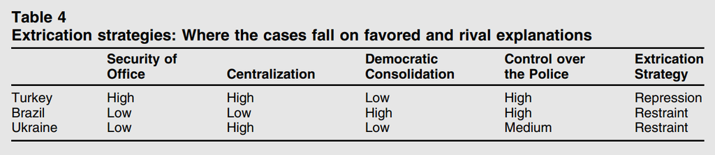

## 💡 Protests and repression

- Question: Why some protests lead to lower repression by government?
- Model: In democracies governments that are less electorally stable expect to be held accountable for their actions and hence will choose to restraint from using violence against protestors
- Hypothesis: Holding other things constant, in Turkey where the government is more electorally secure, we expect higher levels of repressions against protesters compared to Brazil and Ukraine
- Data/Analysis: Comparative case study of Brazil, Turkey and Ukraine during large national uprisings in 2013
- Results: The only considered factor that coincides perfectly with the use of repression against protesters is government’s security in office

## Broockman and Kalla (2024)

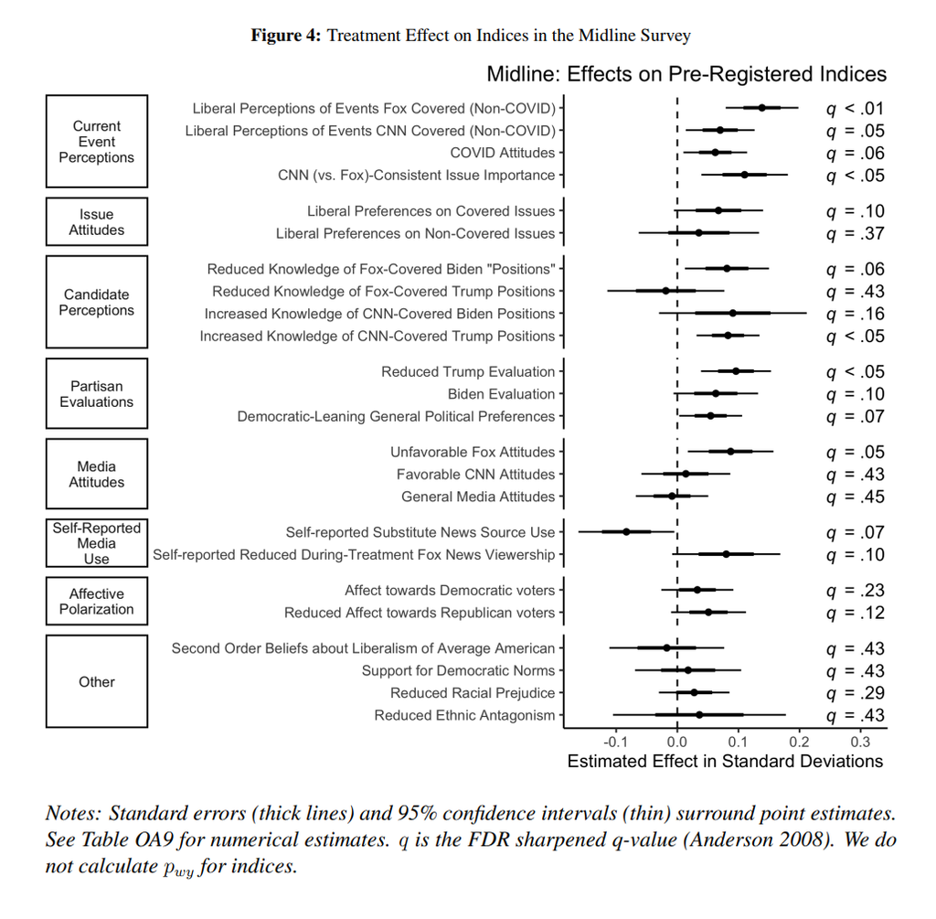

*Many Americans consume aligned partisan media, which scholars worry contributes to polarization. Many propose encouraging these Americans to consume cross-cutting media to moderate their attitudes. However, motivated reasoning theory posits that exposure to crosscutting media could backfire, exacerbating polarization. Building on theories that sustained exposure to novel information can overcome motivated reasoning and that partisan sources on opposite sides cover distinct information, we argue that sustained consumption of crosscutting media leads voters to learn uncongenial information and moderate their attitudes in covered domains. To test this argument, we used data on actual TV viewership to recruit a sample of regular Fox News viewers and incentivized a randomized treatment group to watch CNN instead for a month. Contrary to predictions from motivated reasoning, watching CNN caused substantial learning and moderated participants’ attitudes in covered domains.*

## 💡 Effects of crosscutting media

- Question: How does watching crosscutting media affect political views and beliefs?
- Model: Motivated reasoning theory suggests that there will be no or even a backfire effect of exposure to crosscutting media on political beliefs
- Hypothesis: Exposure to CNN will lead Fox News viewers to realize that Fox News conceals some facts and as a result adjust their media diet and change their attitudes in line with CNN coverage
- Data/Analysis: Online experiment that incentivizes regular Fox News viewers to watch CNN for a month
- Results: Exposure to CNN leads to less trust in Fox News, more agreement with CNN (vs. Fox News) coverage, lower support for Trump

## Reviewing literature

- What do we know about topic related to $X$?
- What do scholars think causes $X$?
- What do scholars think $X$ causes (what are its effects)?
- In research about $X$, do scholars use statistical analysis or case studies?
- Which particular cases do they study?
- The more specific the questions, the easier it will be to organize what you find

## Relying on reputation

- Books from a university press with a reputation
  - *Cambridge*, *Princeton*, *MIT*, *Harvard*, *Cornell*, *Oxford*, *Stanford*, *Michigan*
  - Beware of mimicry by bogus presses (*Cambridge Scholars Publishing* - **bad**, *Cambridge University Press* - **good**)
- Journals with a reputation for publishing good research
  - *American Political Science Review*, *American Journal of Political Science*, *Journal of Politics*, *British Journal of Political Science*, *Political Science Research and Methods*, *Quarterly Journal of Political Science*, *Political Analysis*
  - Subfields: *International Organization*, *Journal of Conflict Resolution*, *International Studies Quarterly*, *Journal of Peace Research*, *World Politics*, *Comparative Political Studies*
  - In Economics: *American Economic Review*, *Quarterly Journal of Economics*, *Econometrica*, *Journal of Political Economy*
  - Especially helpful: *Annual Review of Political Science*, *Journal of Economic Literature*

## Reading yourself

| Section | Content |
| --- | --- |
| Abstract | Short summary-make sure you understand this! |
| Introduction | 1. The questions the paper will try to answer 2. Why it’s important to know those answers 3. A summary of what the answers are and how they were found |
| Theory | 1. The outcome variable (thing to be explained or measured) 2. The independent variables (things that explain outcome) 3. Hypotheses about measure of or effects on outcome |
| Data/Methods | 1. How and what data is collected 2. How variables are measured using this data 3. Technique(s)/Method(s) used to test the hypotheses |
| Results | 1. Do estimated relationships correspond with hypotheses? 2. Statistical and substantive significance of estimates 3. Checks of alternative explanations |
| Conclusion | Broader implications for the field of study |
| Appendix/Replication archive | Usually online: all details needed to verify the procedures and results and possibly to replicate |

## Next week

- Dive into why proving causality is hard
- How to build a map ( *DAG* ) of your theory
- What is operationalization and why is it important

## References

Aytaç, S. Erdem, Luis Schiumerini, and Susan Stokes. 2017. “Protests and Repression in New Democracies.” *Perspectives on Politics* 15 (1): 62–82. https://doi.org/10.1017/S1537592716004138.

Broockman, David, and Joshua Kalla. 2024. “The Manifold Effects of Partisan Media on Viewers’ Beliefs and Attitudes: A Field Experiment with Fox News Viewers.” *Journal of Politics*.

Butler, Daniel M., and David E. Broockman. 2011. “Do Politicians Racially Discriminate Against Constituents? A Field Experiment on State Legislators.” *American Journal of Political Science* 55 (3): 463–77. https://doi.org/10.1111/j.1540-5907.2011.00515.x.

Kenworthy, Lane, and Jonas Pontusson. 2005. “Rising Inequality and the Politics of Redistribution in Affluent Countries.” *Perspectives on Politics* 3 (03). https://doi.org/10.1017/S1537592705050292.

Mendelberg, Tali, Christopher F. Karpowitz, and J. Baxter Oliphant. 2014. “Gender Inequality in Deliberation: Unpacking the Black Box of Interaction.” *Perspectives on Politics* 12 (1): 18–44. https://doi.org/10.1017/S1537592713003691.